# DSCI 100 Final Project

*Edward Huang, Jonathan Lee, Ryan Gao*

## Introduction

There are a variety of factors that can influence an individual's financial situation and their lifestyle. This project aims to predict whether an individual will earn `>50k` or `<=50k` a year based on some factors. We are using the “Adult Data Set” from UCI Machine Learning Repository which contains data on a variety of socioeconomic factors including `age`, `workclass`, `fnlwgt`, `education`, `education_num`, `marital_status`, `occupation`, `relationship`, `race`, `sex`, `capital_gain`, `capital_loss`, `hours_per_week`, and `native_country`. We will use some of these factors as predictors in this analysis to predict an invdividual's `income`. This data is from a census conducted in 1994, and the predictors will be explained in the "Method" section below.

Question: Given a set of predictors pertaining to an individual, will their yearly income be `>50k` or `<=50k`?

## Methods and Results

First, we need to load the appropriate libraries and then transfer the data from the website into R, since the data is hosted on the UCI website. We can do this by using the read_csv function. Since there are currently no titles for any of the columns, we must change this by using the colnames() function. The column names that we are using are found in the attributes section of the "Adult Data Set" website. However, some of them were not clear so we improved upon them.

After column names are applied, the data will be tidy because each variable is in its own column, each observation is in its own row, and each cell has one data point.

```r
library(tidyverse)
library(ggplot2)
library(tidymodels)
library(repr)
library(GGally)
options(repr.matrix.max.rows = 6)
```

[output not shown]

```r
data <- read_csv('https://archive.ics.uci.edu/ml/machine-learning-databases/adult/adult.data')

colnames(data) <- c('age', 'workclass', 'fnlwgt', 'education',
                     'education_yrs', 'marital_status', 'occupation', 'relationship', 'race', 'sex',
                     'capital_gain', 'capital_loss', 'hours_worked_per_week', 'native_country', 'income')

data
```

A spec_tbl_df: 32560 × 15

| age <dbl> | workclass <chr> | fnlwgt <dbl> | education <chr> | education_yrs <dbl> | marital_status <chr> | occupation <chr> | relationship <chr> | race <chr> | sex <chr> | capital_gain <dbl> | capital_loss <dbl> | hours_worked_per_week <dbl> | native_country <chr> | income <chr> |
| --- | --- | --- | --- | --- | --- | --- | --- | --- | --- | --- | --- | --- | --- | --- |
| 50 | Self-emp-not-inc | 83311 | Bachelors | 13 | Married-civ-spouse | Exec-managerial | Husband | White | Male | 0 | 0 | 13 | United-States | <=50K |
| 38 | Private | 215646 | HS-grad | 9 | Divorced | Handlers-cleaners | Not-in-family | White | Male | 0 | 0 | 40 | United-States | <=50K |
| 53 | Private | 234721 | 11th | 7 | Married-civ-spouse | Handlers-cleaners | Husband | Black | Male | 0 | 0 | 40 | United-States | <=50K |
| ⋮ | ⋮ | ⋮ | ⋮ | ⋮ | ⋮ | ⋮ | ⋮ | ⋮ | ⋮ | ⋮ | ⋮ | ⋮ | ⋮ | ⋮ |
| 58 | Private | 151910 | HS-grad | 9 | Widowed | Adm-clerical | Unmarried | White | Female | 0 | 0 | 40 | United-States | <=50K |
| 22 | Private | 201490 | HS-grad | 9 | Never-married | Adm-clerical | Own-child | White | Male | 0 | 0 | 20 | United-States | <=50K |
| 52 | Self-emp-inc | 287927 | HS-grad | 9 | Married-civ-spouse | Exec-managerial | Wife | White | Female | 15024 | 0 | 40 | United-States | >50K |

*Table 1.0* The "Adult Data Set" from the UCI Machine Learning Repository with Added Column Names

### Checking for NAs

We will check for NAs in the dataset and deal with them if there are any found. We will use the function 'sum(is.na(data_new))' which will return the number of NAs in the dataset.

```r
sum(is.na(data))
```

0

Luckily there were no NAs in the data so no further data tidying is necessary.

### Variable Definitions

Before we proceed with our preliminary data analysis, we need to understand what each of the columns represents. While some of the variables are self-explanatory, such as `age`, `race`, and `sex`, some of them still need to be clarified.

In this dataset, `fnlwgt` denotes the final weight, which is a numerical value that is used for scaling purposes in the census.

The variables `capital_gain` and `capital_loss` represent the income generated aside from each individual’s salary.

### Choosing Predictors

We exclude all non-numerical variables to keep things simple, because it is difficult to compute the distance between categorical variables. Additionally, `capital_gain` and `capital_loss` are not included because they change year to year and are not consistent.

Since the only purpose of the variable `fnlwgt` is to assign weights to similar demographics and therefore has no predictive capability, we chose to exclude it as well.

So, we are left with four remaining variables: `hours_worked_per_week`, `education_yrs`, `age`, and `income`.

Additionally, we also must convert the target variable, `income` into a factor because it is the categorical class that we are predicting for.

```r
data_new <- data %>%
select(hours_worked_per_week, education_yrs, age, income) %>%
mutate(income = as.factor(income))

data_new
```

A tibble: 32560 × 4

| hours_worked_per_week <dbl> | education_yrs <dbl> | age <dbl> | income <fct> |
| --- | --- | --- | --- |
| 13 | 13 | 50 | <=50K |
| 40 | 9 | 38 | <=50K |
| 40 | 7 | 53 | <=50K |
| ⋮ | ⋮ | ⋮ | ⋮ |
| 40 | 9 | 58 | <=50K |
| 20 | 9 | 22 | <=50K |
| 40 | 9 | 52 | >50K |

*Table 1.1* Possible Predictor Variables

Then, we can perform a `ggpairs` analysis to precisely determine the predictors we will be using.

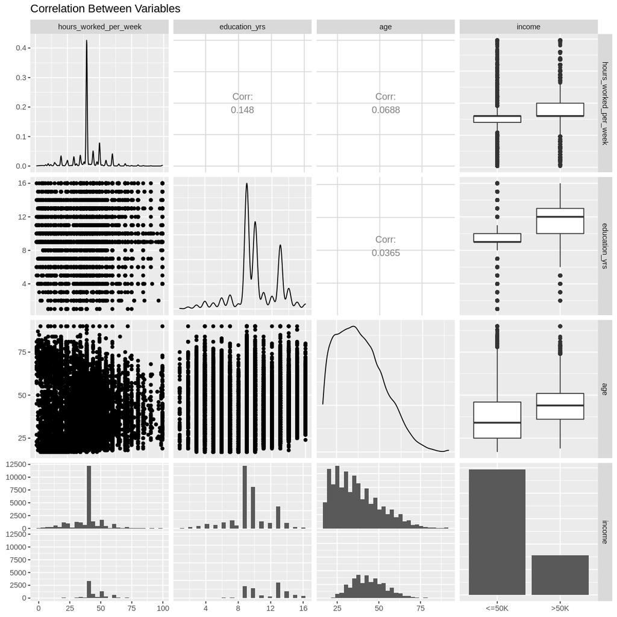

```r
options(repr.plot.width = 10, repr.plot.height = 10)
corr_plot <- ggpairs(data_new) +
    ggtitle("Correlation Between Variables")
corr_plot
```

*Figure 1.0* `ggpairs` Analysis for Possible Predictor Variables

One thing that is of note is the peak in the `hours_work_per_week` distribution. The one visible peak appears to be at ~40 hours per week, which makes sense as a 40 hour workweek is the norm. This means that the distribution for `hours_worked_per_week` is significantly influenced by one data point, so it is not a reliable predictor.

Thus, the predictors we will use for the analysis are `age` and `education_yrs`, so we can remove `hours_worked_per_week` from the data frame.

```r
data_new <- data_new %>%
select(-hours_worked_per_week)
```

### Summary of Data Set

Here, we will perform some calculations on the data to summarize it and collect some statistics that may be relevant to the data analysis.

First, we must split the data into testing and training sets, with 75 percent of the data as training and 25 percent as testing.

```r
set.seed(2020)

data_split <- initial_split(data_new, prop = 0.75, strata = income)
data_train <- training(data_split)
data_test <- testing(data_split)
```

```r
data_train
```

A tibble: 24421 × 3

| education_yrs <dbl> | age <dbl> | income <fct> |
| --- | --- | --- |
| 13 | 50 | <=50K |
| 9 | 38 | <=50K |
| 7 | 53 | <=50K |
| ⋮ | ⋮ | ⋮ |
| 9 | 58 | <=50K |
| 9 | 22 | <=50K |
| 9 | 52 | >50K |

*Table 1.2* Training Data

Now we can create a histogram which shows the distribution of ages in the data, and colour by income, to see if there are any relationships.

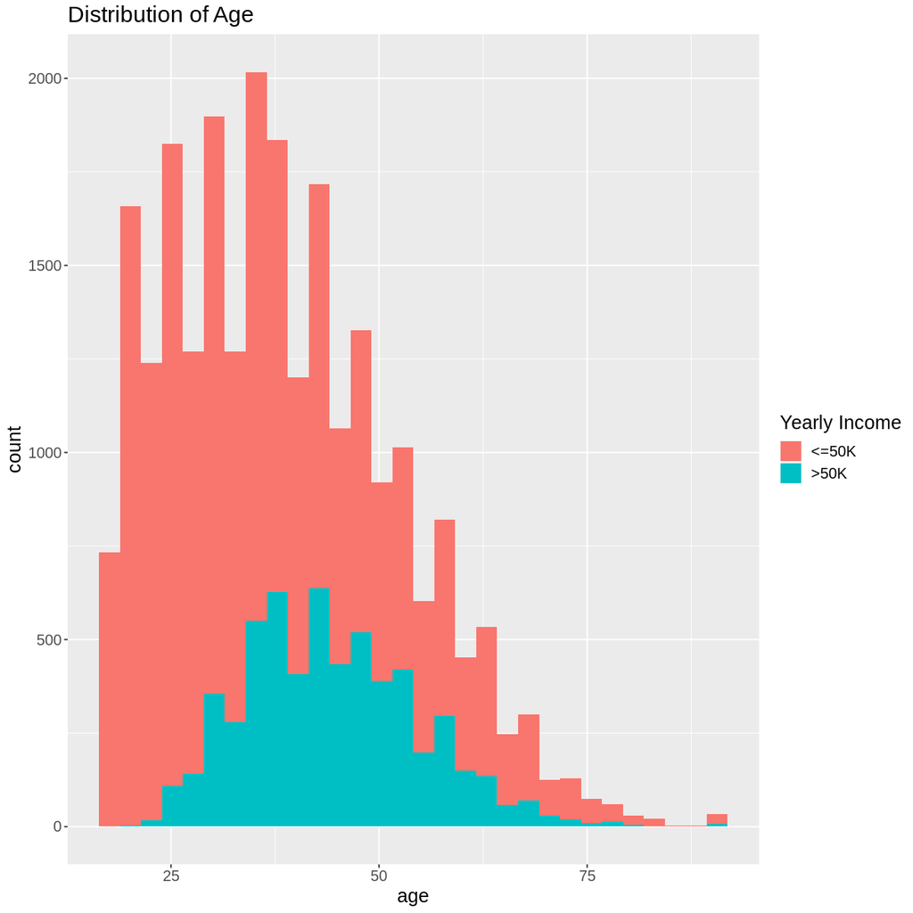

```r
age_income_hist <- data_train %>%
    ggplot(aes(x = age, fill = income)) +
    geom_histogram() +
    ggtitle("Distribution of Age") +
    labs("Age (Years)", fill = "Yearly Income") +
    theme(text = element_text(size = 15))

age_income_hist
```

*Figure 1.1* Distribution of Ages Sorted Coloured by Yearly Income

We can also make a histogram which shows the distribution of years of education in the dataset and colour by income.

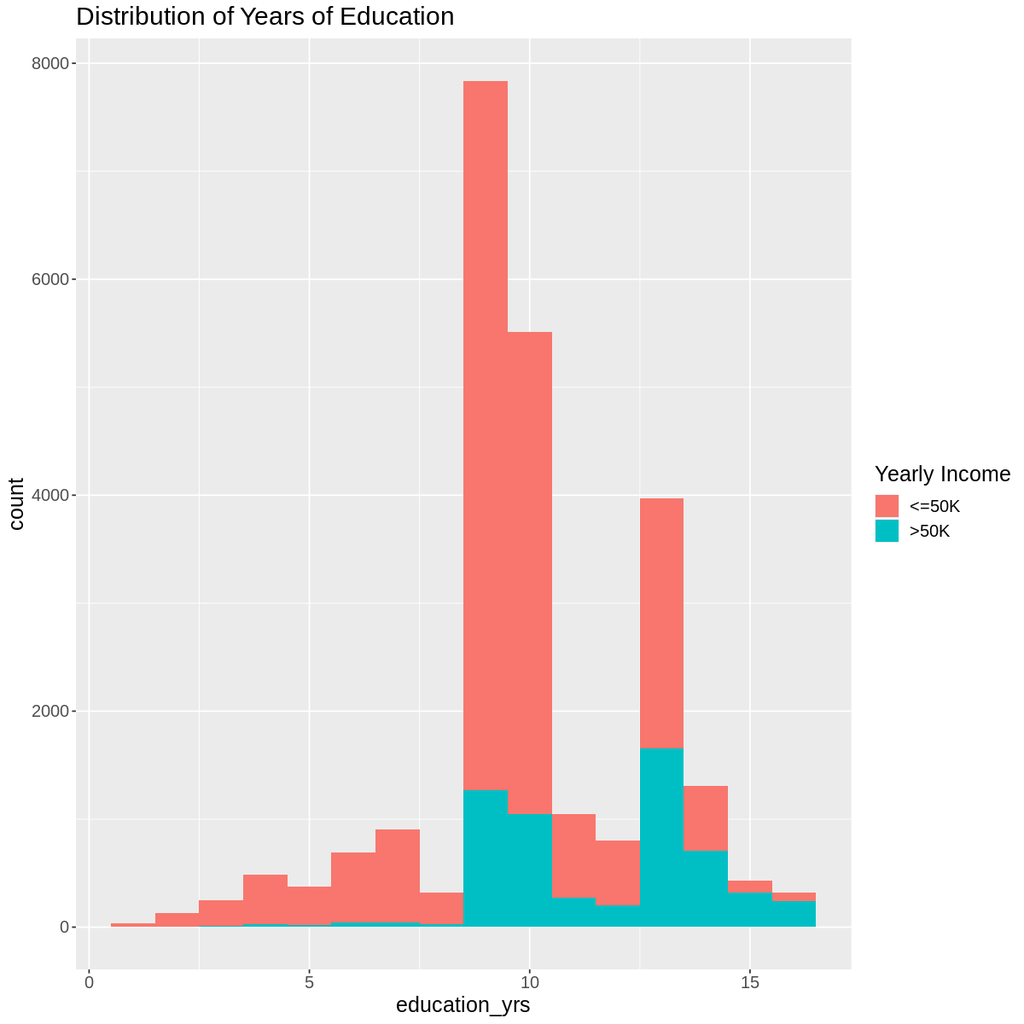

```r
education_income_hist <- data_train %>%
    ggplot(aes(x = education_yrs, fill = income)) +
    geom_histogram(binwidth = 1) +
    ggtitle("Distribution of Years of Education") +
    labs("Age (Years)", fill = "Yearly Income") +
    theme(text = element_text(size = 15))

education_income_hist
```

*Figure 1.2* Distribution of Years of Education Coloured by Yearly Income

We can calculate the mean, median, and standard deviation of age of people in the data set.

```r
age_statistics <- data_train %>%
    summarize(avg_age = mean(age),
              med_age = median(age),
              sd_age = sd(age))
age_statistics
```

A tibble: 1 × 3

| avg_age <dbl> | med_age <dbl> | sd_age <dbl> |
| --- | --- | --- |
| 38.58765 | 37 | 13.71596 |

*Table 1.3* Mean, Median, and Standard Deviation of Age

We can also calculate the mean, median, and standard deviation of the average years of education of people in the data set.

```r
education_statistics <- data_train %>%
    summarize(avg_education = mean(education_yrs),
              med_education = median(education_yrs),
              sd_education = sd(education_yrs))
education_statistics
```

A tibble: 1 × 3

| avg_education <dbl> | med_education <dbl> | sd_education <dbl> |
| --- | --- | --- |
| 10.08214 | 10 | 2.572672 |

*Table 1.4* Mean, Median, and Standard Deviation of Years of Education

Here, we calculate the percentage of people who made `>50K` in the data set to give us an idea of the data we are working with.

```r
over_50k <- data_train %>%
    filter(income == ">50K") %>%
    summarize(n = n()) %>%
    pull(n)

under_50k <- data_train %>%
    filter(income == "<=50K") %>%
    summarize(n = n()) %>%
    pull(n)

over_50k_percent <- (over_50k / (over_50k + under_50k))
over_50k_percent
```

0.240817329347693

Approximately 24% of people made `>50K` in the data set. Conversely, this means that approximately 76% of people made `<=50K` in the data set.

Here, we calculate the range of values for age in the data set.

```r
max_age <- data_train %>%
summarize(max_value = max(age)) %>%
    pull(max_value)

min_age <- data_train %>%
summarize(min_value = min(age)) %>%
    pull(min_value)

age_range <- cat("[", min_age, ",", max_age, "]")
```

```
[ 17 , 90 ]
```

We can see that the youngest person in the data set is 17 years old while the oldest is 90.

Here, we calculate the range of values for years of education in the data set.

```r
max_education <- data_train %>%
summarize(max_value = max(education_yrs)) %>%
    pull(max_value)

min_education <- data_train %>%
summarize(min_value = min(education_yrs)) %>%
    pull(min_value)

education_range <- cat("[", min_education, ",", max_education, "]")
```

```
[ 1 , 16 ]
```

We see that the least years of education anyone had in the dataset was 1 year, while the most was 16 years.

### Building the Classifier

We need to preprocess the data, specifically centering and scaling predictors. We will do this by creating a recipe.

```r
set.seed(2020)

income_recipe <- recipe(income ~ education_yrs + age , data = data_train) %>%
   step_scale(all_predictors()) %>%
   step_center(all_predictors())
income_recipe
```

```
Data Recipe

Inputs:

      role #variables
   outcome          1
 predictor          2

Operations:

Scaling for all_predictors()
Centering for all_predictors()
```

We will now find the optimal value of k for the classifier. The first step will be to perform cross-validation on the training data, and we will use 5 folds.

```r
set.seed(2020)

income_vfold <- vfold_cv(data_train, v = 5, strata = income)
```

Build the tune model, specifying the engine as `kknn` and mode as `classification` because we are doing a classification problem. We set neighbors to `tune()` because we have not chosen `k` yet.

```r
set.seed(2020)

knn_tune <- nearest_neighbor(weight_func = "rectangular", neighbors = tune()) %>%
      set_engine("kknn") %>%
      set_mode("classification")
knn_tune
```

```
K-Nearest Neighbor Model Specification (classification)

Main Arguments:
  neighbors = tune()
  weight_func = rectangular

Computational engine: kknn
```

Now, we can run cross-validation across the folds with the tune model made and the recipe made earlier, `income_recipe`. We use `collect_metrics` to collect the results of the cross-validation. The cross-validation takes around 2 minute 20 seconds to run on our computer, due to the size of the data set.

```r
set.seed(1234)

knn_results <- workflow() %>%
      add_recipe(income_recipe) %>%
      add_model(knn_tune) %>%
      tune_grid(resamples = income_vfold, grid = 10) %>%
      collect_metrics()

knn_results
```

A tibble: 20 × 7

| neighbors <int> | .metric <chr> | .estimator <chr> | mean <dbl> | n <int> | std_err <dbl> | .config <chr> |
| --- | --- | --- | --- | --- | --- | --- |
| 2 | accuracy | binary | 0.7130348 | 5 | 0.006658361 | Model01 |
| 2 | roc_auc | binary | 0.6567686 | 5 | 0.002340096 | Model01 |
| 3 | accuracy | binary | 0.7530815 | 5 | 0.002520411 | Model02 |
| ⋮ | ⋮ | ⋮ | ⋮ | ⋮ | ⋮ | ⋮ |
| 13 | roc_auc | binary | 0.7721559 | 5 | 0.002535469 | Model09 |
| 14 | accuracy | binary | 0.7795753 | 5 | 0.003153200 | Model10 |
| 14 | roc_auc | binary | 0.7762489 | 5 | 0.002517391 | Model10 |

*Table 1.5* Results from Cross-Validation with 5 Folds

We want to know the accuracies that different values of k produces, so we filter the results for accuracy.

```r
set.seed(1234)
accuracies <- knn_results %>%
      filter(.metric == "accuracy")
accuracies
```

A tibble: 10 × 7

| neighbors <int> | .metric <chr> | .estimator <chr> | mean <dbl> | n <int> | std_err <dbl> | .config <chr> |
| --- | --- | --- | --- | --- | --- | --- |
| 2 | accuracy | binary | 0.7130348 | 5 | 0.006658361 | Model01 |
| 3 | accuracy | binary | 0.7530815 | 5 | 0.002520411 | Model02 |
| 4 | accuracy | binary | 0.7548835 | 5 | 0.003414665 | Model03 |
| ⋮ | ⋮ | ⋮ | ⋮ | ⋮ | ⋮ | ⋮ |
| 12 | accuracy | binary | 0.7766677 | 5 | 0.00178746 | Model08 |
| 13 | accuracy | binary | 0.7798618 | 5 | 0.00264363 | Model09 |
| 14 | accuracy | binary | 0.7795753 | 5 | 0.00315320 | Model10 |

*Table 1.6* Accuracies of Predictions for Different Values of `k`

Now we will plot the accuracies against `k` to find the optimal level for `k`.

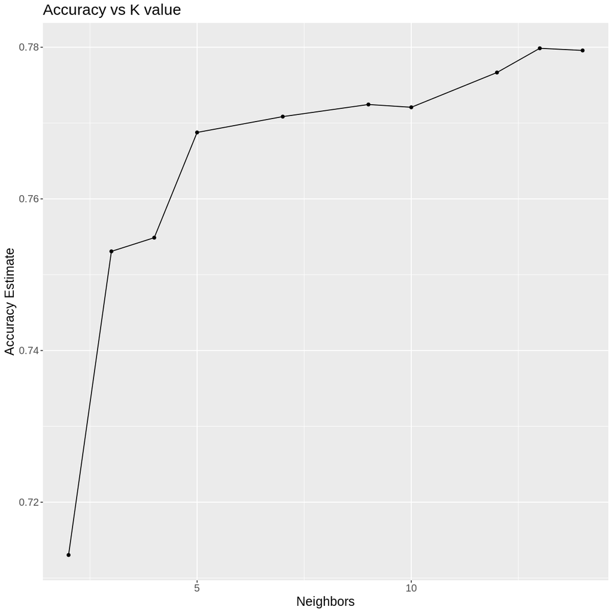

```r
accuracy_versus_k <- ggplot(accuracies, aes(x = neighbors, y = mean))+
    geom_point() +
    geom_line() +
    labs(x = "Neighbors", y = "Accuracy Estimate") +
    ggtitle("Accuracy vs K value") +
    theme(text = element_text(size = 15))
accuracy_versus_k
```

*Figure 1.3* Graph of Accuracies Versus Number of Neighbors `k`

```r
k_val <- accuracies %>%
    arrange(desc(mean)) %>%
    select(neighbors) %>%
    slice(1) %>%
    pull()
k_val
```

13

The optimal `k` value is indeed 13. We will now build our classifier with the best value of `k`.

```r
set.seed(2020)
income_spec_best <- nearest_neighbor(weight_func = "rectangular", neighbors = k_val) %>%
      set_engine("kknn") %>%
      set_mode("classification")

income_best_fit <- workflow() %>%
      add_recipe(income_recipe) %>%
      add_model(income_spec_best) %>%
      fit(data = data_train)
income_best_fit
```

```
══ Workflow [trained] ══════════════════════════════════════════════════════════
Preprocessor: Recipe
Model: nearest_neighbor()

── Preprocessor ────────────────────────────────────────────────────────────────
2 Recipe Steps

● step_scale()
● step_center()

── Model ───────────────────────────────────────────────────────────────────────

Call:
kknn::train.kknn(formula = ..y ~ ., data = data, ks = ~k_val,     kernel = ~"rectangular")

Type of response variable: nominal
Minimal misclassification: 0.2126039
Best kernel: rectangular
Best k: 13
```

Now we can try predicting on our testing data with the new model. We will bind the classifier's predictions to the testing data to compare with the true value of the income.

```r
set.seed(2020)

income_test_best_predictions <- predict(income_best_fit, data_test) %>%
      bind_cols(data_test)
income_test_best_predictions
```

A tibble: 8139 × 4

| .pred_class <fct> | education_yrs <dbl> | age <dbl> | income <fct> |
| --- | --- | --- | --- |
| <=50K | 13 | 28 | <=50K |
| <=50K | 5 | 49 | <=50K |
| <=50K | 10 | 37 | >50K |
| ⋮ | ⋮ | ⋮ | ⋮ |
| <=50K | 9 | 41 | <=50K |
| <=50K | 12 | 39 | >50K |
| <=50K | 6 | 32 | <=50K |

*Table 1.7* Testing Data with .pred_class Column Added

Now we will calculate how accurate our classifier was over the testing data.

```r
set.seed(2020)

income_prediction_accuracy <- income_test_best_predictions %>%
        metrics(truth = income, estimate = .pred_class)

income_prediction_accuracy
```

A tibble: 2 × 3

| .metric <chr> | .estimator <chr> | .estimate <dbl> |
| --- | --- | --- |
| accuracy | binary | 0.7784740 |
| kap | binary | 0.3082427 |

*Table 1.7* Metrics of Classifier's Predictions on Testing Data

The classifier's accuracy predicting over the testing data was around 78 percent accurate. We will also view the confusion matrix to see the amount of correct and incorrect predictions made.

```r
set.seed(2020)

income_prediction_mat <- income_test_best_predictions %>%
      conf_mat(truth = income, estimate = .pred_class)

income_prediction_mat
```

```
          Truth
Prediction <=50K >50K
     <=50K  5634 1258
     >50K    545  702
```

*Figure 1.5* Confusion Matrix Showing Correct and Incorrect Predictions from Model

The classifier predicted `<=50k` 5634 times correctly and 1258 times incorrectly, and predicted `>50k` 702 times correctly and 545 times incorrectly.

Now we will use the classifier to predict the income level of an 18 year-old university student. We will basically predict on ourselves. To do this we will make a tibble representing the above information and then predict on it with the classifier.

```r
me <- tibble(age = 18, education_yrs = 13)
predict_me <- predict(income_best_fit, me)
predict_me
```

A tibble: 1 × 1

| .pred_class <fct> |
| --- |
| <=50K |

The classifier predicted that I will make `<=50K`, which is obvious and correct. We will visualize this point in the data. The circled point is the 'me' data point.

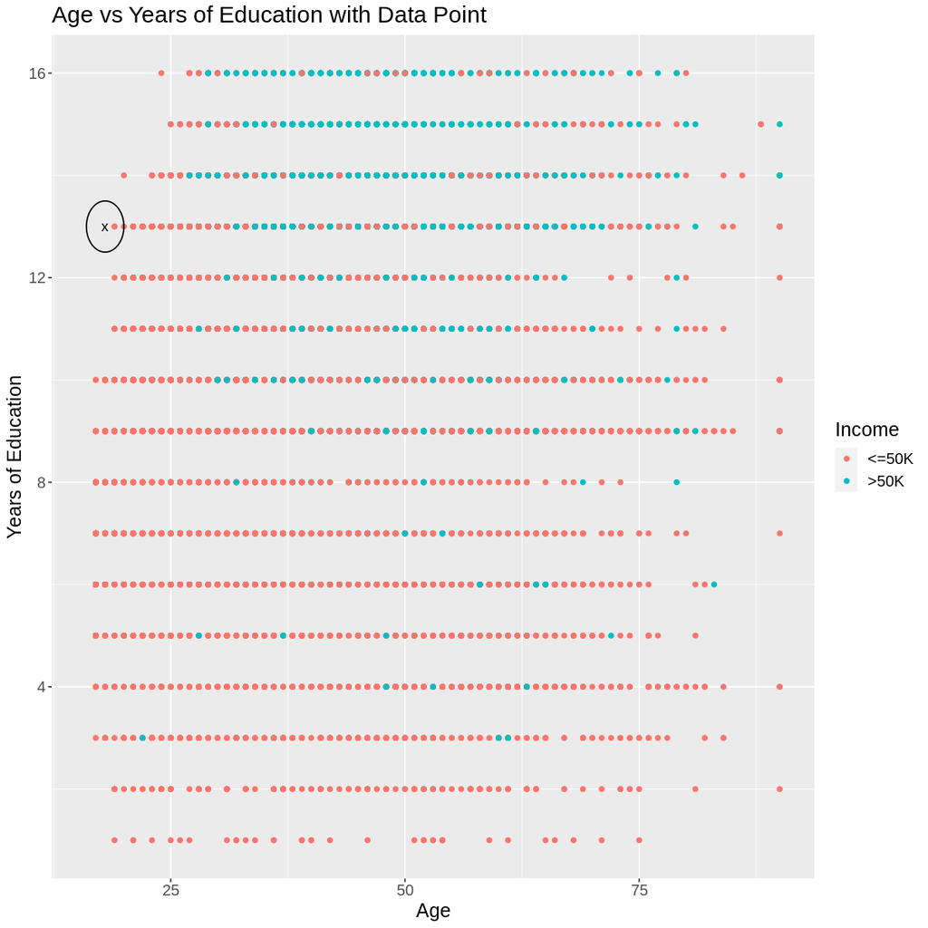

```r
new_obs <- c(18, 13)

final_visualization <- data_train %>%
ggplot(aes(x = age, y = education_yrs, color = income)) +
geom_point() +
labs(x = "Age", y = "Years of Education", color = "Income") +
theme(text = element_text(size = 15)) +
ggtitle("Age vs Years of Education with Data Point") +
annotate("path", x=new_obs[1] + 2 * cos(seq(0,2 * pi,length.out=100)),
                 y=new_obs[2] + 0.5 * sin(seq(0,2 * pi,length.out=100))) +
        annotate("text", x = 18, y =  13, label = "x")
final_visualization

#annotate code is from worksheet 6
```

*Figure 1.6* Visualization of a New Data Point

Now we can try predicting on someone who is 55 and has 14 years of education. We will again make a tibble representing the person and predict on it with the classifier.

```r
old_person <- tibble(age = 55, education_yrs = 14)
predict_old_person <- predict(income_best_fit, old_person)
predict_old_person
```

A tibble: 1 × 1

| .pred_class <fct> |
| --- |
| >50K |

The classifier predicted that this person will make `>50K`, which falls in line with the distributions illustrated in Figure 1.1 and 1.2.

## Discussion

Now, we can plot a scatterplot of our predictions to see if any trends are able to be discerned.

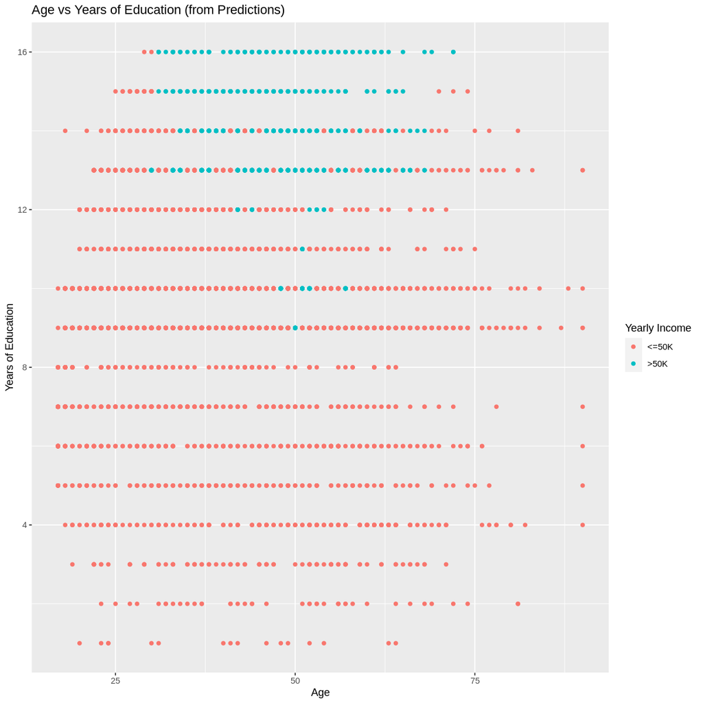

```r
predictions_plot <- income_test_best_predictions %>%
    ggplot(aes(x = age, y = education_yrs, colour = .pred_class)) +
    geom_point() +
    ggtitle("Age vs Years of Education (from Predictions)") +
    labs(x = "Age", y = "Years of Education", colour = "Yearly Income")
predictions_plot
```

This result makes sense because generally, people who attend or graduate from university get access to higher paying jobs than people with only a high school education. Additionally, as people age, they progress in their careers which is usually done through promotion at their jobs or receiving more competitive salaries at other companies. All of this culminates in a higher yearly income.

This result also aligns with current census data. According to census data from Canada in 2016, women with a bachelor's degree earned significantly more than women with other education levels, earning 40% more than women with only an associate's degree, and 60% more than women with only a high school level education ("Census in Brief").

An extension to this project would be to analyze some of the predictors themselves, particularly the ones which we did not factor into our classifier because they were not numeric for simplicity's sake. For instance, we could analyze `race` and `sex` to view the relationship between race and gender and see if there is any wealth disparity that is visible in the data. However, in order to do this, we would likely have to gather more data from underrepresented groups, as the current data set that we have has more data collected from white males than any other group. Barring that, for example, if it was found that most people with a high `education_num` were of a certain `race` and `sex`, then governing bodies may want to take action to reduce this inequality and increase the representation of minorities at higher education institutions.

## Works Cited

Government of Canada, Statistics Canada. Census in Brief: Does Education Pay? A Comparison of Earnings by Level of Education in Canada and Its Provinces and Territories. 29 Nov. 2017, https://www12.statcan.gc.ca/census-recensement/2016/as-sa/98-200-x/2016024/98-200-x2016024-eng.cfm. Accessed 3 Dec. 2021.

Roser, Max, and Esteban Ortiz-Ospina. “Financing Education.” Our World in Data, June 2016. ourworldindata.org, https://ourworldindata.org/financing-education. Accessed 3 Dec. 2021.

UCI Machine Learning Repository: Adult Data Set. https://archive.ics.uci.edu/ml/datasets/adult. Accessed 6 Nov. 2021.